# Comparison of the linear regression and KNN models

Michael Weatherford

2025-06-08

# Comparison of the linear regression and KNN models

## 1. Set Up

First checking the distribution of the data.

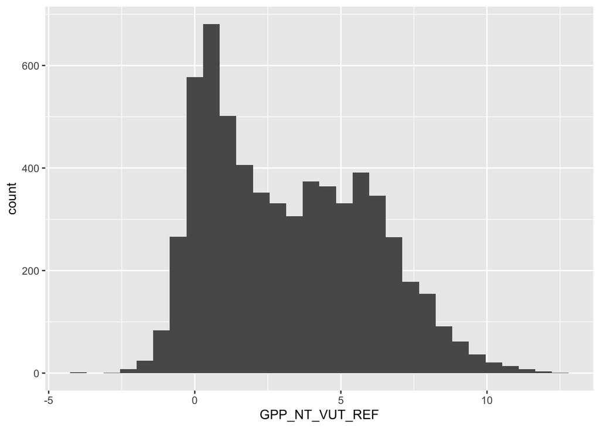

### Running the models

Linear regression

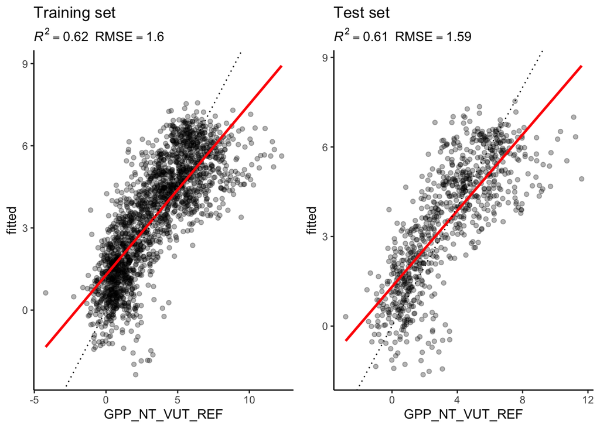

KNN

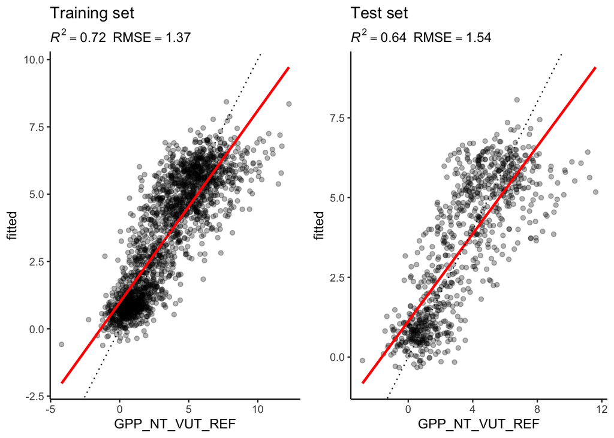

## 2. Interpret observed differences in the context of the bias-variance trade-off:

The test and training are closer to the linear regression because linear regression is a more fixed/simpler model which allows it to get a generally good estimate based on a random split of the data. For KNN because it is normally used for categorizing data it is very malleable with training data but when attempting to apply it to the test set it seems to not represent the data as well.

The evaluation test set indicates the best model performance overall to be the KNN training set while this may seem it good it may be sign that the model is over fitting. This could be due to the flexibility of the model that allows it to fit training sets well but when applied to test sets it fails. The linear regression on the other hand performs very similarly between the two sets indicating a much more general application.

I would put the KNN model closer to the variance side of the spectrum and LM closer to the bias side as it seems the KNN model captures more of the random variance in the data while the LM is further away from the training sets but stays consistent when applied to the test set.

## 3. Visualise temporal variations of observed and modelled GPP for both models, covering all available dates.

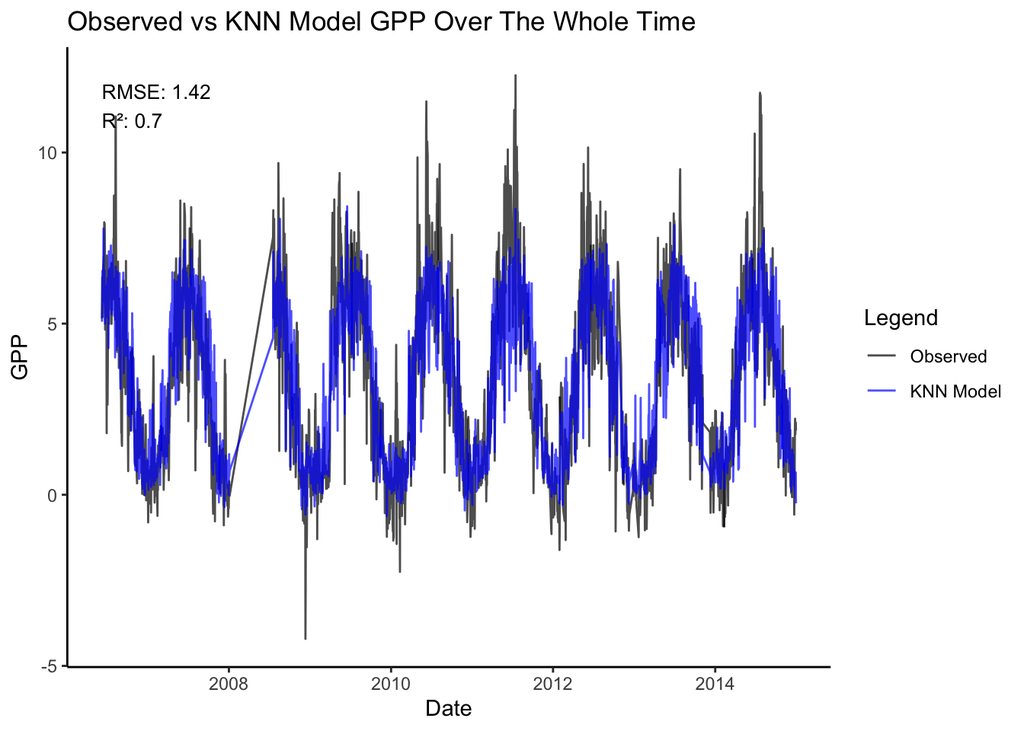

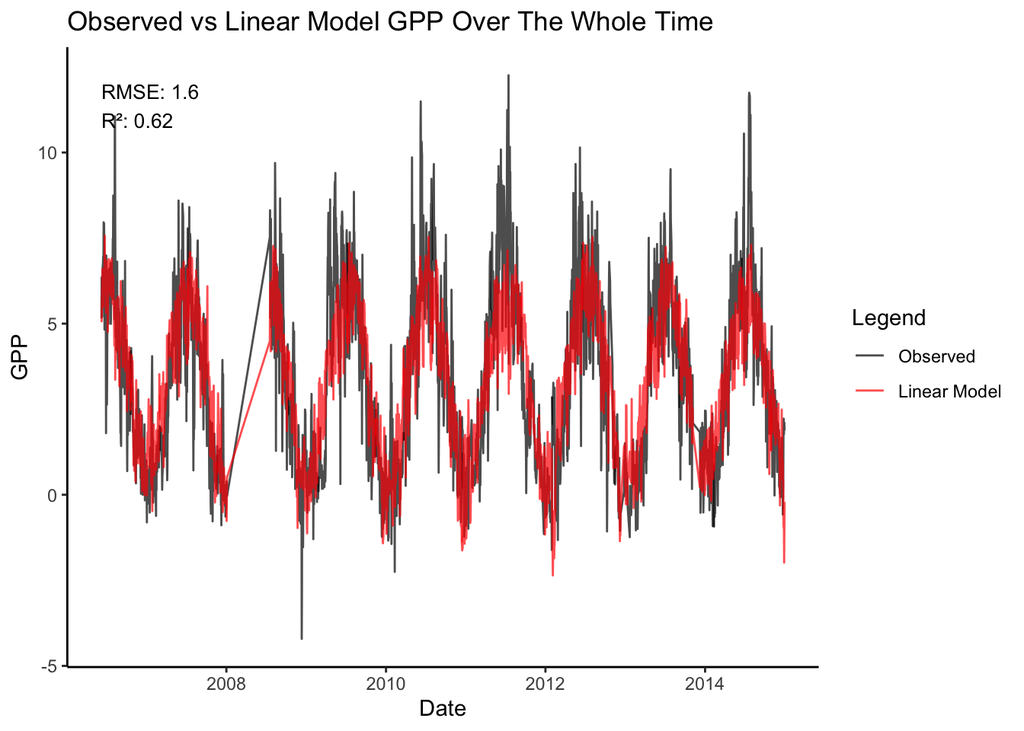

# The Role of K

## 1. Based on your understanding of KNN (and without running code), state a hypothesis for how the R^2 and the MAE evaluated on the test and on the training set would change for k approaching 1 and for k approaching N (the number of observations in the data). Explain your hypothesis, referring to the bias-variance trade-off.

My hypothesis is that when it comes to the training set the MAE would decrease quickly and then slowly as K decreases. This is due to the model becoming more fitted and then over fitted to the data. I believe for the test data there will be an optimal value somewhere in the middle as MAE will decrease at first and then start to increase once the model is trained more so on variance in the data than the actual trends of the data. Because if k=1 than the model is just fitted to the closest neighbor where as a higher k gives a more general trend.

## 2.Put your hypothesis to the test! Write code that splits the data into a training and a test set and repeats model fitting and evaluation for different values for. Visualize results, showing model generalisability as a function of model complexity. Describe how a “region” of overfitting and underfitting can be determined in your visualisation. Write (some of your) code into a function that takes k as an input and and returns the MAE determined on the test set.

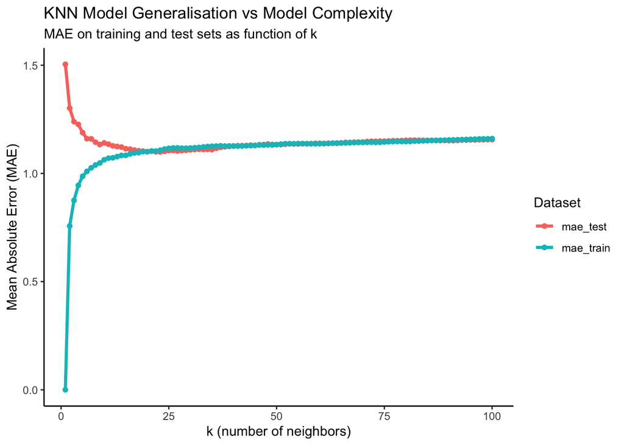

Wherever the training and testing MAE are far apart represents a region of overfitting as the data matches the training too much. Where the test data has a lower MAE than the training data may represent a region of underfitting as the model is too general as k approaches the total number of data points it just becomes an average of all the points. Thus making sure K isn’t close to N can help

## 3. Is there an “optimal” in terms of model generalisability? Edit your code to determine an optimal k.

```r
optimal_k <- mae_results |>
  filter(mae_test == min(mae_test))
print(optimal_k)
```

```
## # A tibble: 1 × 3
##       k mae_test mae_train
##   <int>    <dbl>     <dbl>
## 1    23     1.10      1.11
```